# Probability and Statistics

# Lab Assignment 1: Naive Bayes Classifier

### *Yaroslav Korch, Yaroslav Tkachuk*

## Introduction

During the past three weeks, you learned a couple of essential notions and theorems, and one of the most important among them is the *Bayes theorem*.

One of its applications is **Naive Bayes classifier**, which is a probabilistic classifier whose aim is to determine which class some observation probably belongs to by using the Bayes formula:
$$\mathsf{P}(\mathrm{class}\mid
\mathrm{observation})=\frac{\mathsf{P}(\mathrm{observation}\mid\mathrm{class})\mathsf{P}(\mathrm{class})}{\mathsf{P}(\mathrm{observation})}$$

Under the strong independence assumption, one can calculate $\mathsf{P}(\mathrm{observation} \mid \mathrm{class})$ as
$$\mathsf{P}(\mathrm{observation}) =
\prod_{i=1}^{n} \mathsf{P}(\mathrm{feature}_i), \qquad
\mathsf{P}(\mathrm{observation} \mid \mathrm{class}) = \prod_{i=1}^{n}
\mathsf{P}(\mathrm{feature}_i \mid \mathrm{class}),$$
where $n$ is the total number of features describing a given observation. Thus, $\mathsf{P}(\mathrm{class}|\mathrm{observation})$ now can be calculated as

$$\mathsf{P}(\mathrm{class} \mid
\mathrm{\mathrm{observation}}) = \mathsf{P}(\mathrm{class})\times
\prod_{i=1}^{n}\frac{\mathsf{P}(\mathrm{feature}_i\mid
\mathrm{class})}{\mathsf{P}(\mathrm{feature}_i)}\tag{1}$$

All the terms on the right-hand side can be estimated from the data as respective relative frequencies;  
see [this site](https://monkeylearn.com/blog/practical-explanation-naive-bayes-classifier/) for more detailed explanations.

## Data description

### 9-th team = 4 (mod 5)

- **4 - spam** This last data set contains SMS messages classified as spam or non-spam (ham in the data set). The task is to determine whether a given message is spam or non-spam.

## *train.csv* is used to build a bag-of-words, while *test.csv* - to see how well the Bayes Classifier works

```r
# here goes a list of recommended libraries,
# though you may install other ones if they are needed
library(tidytext)
library(readr)
library(dplyr)
```

```r
library(ggplot2)
library(wordcloud)
```

## Instructions

- The first step is data pre-processing, which includes removing punctuation marks and stop words
- represent each message as a bag-of-words
- using the training set, calculate all the conditional probabilities in formula (1)
- use those to predict classes for messages in the test set
- evaluate effectiveness of the classifier by calculating the corresponding metrics
- shortly summarize your work
- do not forget to submit both the (compiled) Rmd source file and the .html output

## Linking all needed files and parsing stop words:

```r
test_path <- "data/4-spam/test.csv"
train_path <- "data/4-spam/train.csv"

stop_words <- read_file("stop_words.txt")
splitted_stop_words <- strsplit(stop_words, split="[\r\n|\n]")
splitted_stop_words <- splitted_stop_words[[1]]
```

## Reading these files:

```r
train <-  read.csv(file = train_path, stringsAsFactors = FALSE)
test <-  read.csv(file = test_path, stringsAsFactors = FALSE)
```

##### Reforming the data into practical representation. Splitting each Message into list of words, and then combining all of them to one bag-of-words (df). Then, separating spam and non-spam parts of train df

```r
# note the power functional features of R bring us!
tidy_text <- unnest_tokens(train, output = 'word', input ='Message') %>%
             filter(!word %in% splitted_stop_words)

df <- tidy_text %>% count(word, sort=TRUE)

df_with_categories <- tidy_text %>% count(Category, word, sort=TRUE)
spam_df <- df_with_categories %>% filter(Category=="spam")
non_spam_df <- df_with_categories %>% filter(Category=="ham")
```

# Classifier implementation

Splitting the test data in two parts for easier access to true positives, false positives …

Calculating the ratio of spam or non-spam in a given training data

```r
spam_test_df = test %>% filter(Category=="spam") %>% count(Category, Message, result=1)
ham_test_df = test %>% filter(Category=="ham") %>% count(Category, Message, result=1)
is_spam = nrow(train %>% filter(Category=="spam"))/nrow(train)
is_not_spam = 1 - is_spam
```

**Method fit** - tests how well the Classifier works (runs the test data and records the results)

**Fields X_test and y_test** serve to save these tests. They have one additional column - for the result. The result is 1 if a message was identified correctly. For test dataframe with spam message the correct prediction is 0 because 0 corresponds to spam, while 1 - to non-spam. This is why in test dataframe with non-spam the correct prediction is 1.

**Method predict** - predicts a message (spam or not). Input - a table 3x1 (Category, Message, result).

**Method score** - Builds plots for better understanding of program’s effectiveness.

```r
naiveBayes <- setRefClass("naiveBayes",

        # X_test - for spam, y_test - for ham (non-spam)
       fields = list(X_test="data.frame", y_test="data.frame"),

       methods = list(
                    fit = function()
                    {
                      for (row in 1:nrow(spam_test_df)){
                        val = predict(spam_test_df[row, -4])
                        if (val == 1){
                          spam_test_df[row, "result"] = 0
                        }
                      }
                      for (row in 1:nrow(ham_test_df)){
                        val = predict(ham_test_df[row, -4])
                        if (val == 0){
                            ham_test_df[row, "result"] = 0
                        }
                      }
                        X_test <<- spam_test_df
                        y_test <<- ham_test_df
                    },

                    # returns prediction for a single message
                    # 0 - spam, 1 - non-spam
                    predict = function(message)
                    {
                         #TODO: split message into words, for each list calc the probability, return the highest
                      words <- unnest_tokens(message, output = 'word', input = 'Message')
                      dfs <- list(spam_df, non_spam_df)
                      res <- list(0, 0)
                      for (ind in 1:2){
                        curr_df <- dfs[[ind]]
                        sum <- 1
                        for (row in 1:nrow(words)) {
                            sum <- sum * calc_probability(words[row, "word"], curr_df)
                        }
                        if (ind == 1){
                          res[[1]] = sum * is_spam
                        }
                        else{
                          res[[2]] = sum * is_not_spam
                        }
                      }
                      if (res[[1]] > res[[2]]){
                        return(0)
                      }
                      return(1)
                    },
                    predict_from_string= function(string){
                        temp_df = data.frame(Category='unknown', Message=string, result=1)
                        return(predict(temp_df))
                    },

                    # calculates the probability for a single word
                    calc_probability = function (word, cur_df){
                        pos <- which(cur_df["word"] == word)
                        divisor <- nrow(cur_df) + nrow(df)
                        if (length(pos) == 0){
                          return(1/divisor)
                        }
                        else {
                          occurences = cur_df["n"][pos, ]
                          return ((1+occurences)/divisor)
                        }
                    },

                    # score you test set so to get the understanding how well you model
                    # works.
                    # look at f1 score or precision and recall
                    # visualize them
                    # try how well your model generalizes to real world data!
                    score = function()
                      {
                      #X_Test - identified as spam
                      #y_test - identified as ham
                      spam_true <- X_test[X_test$result == TRUE, ]
                      spam_true_amount <- nrow(spam_true)

                      ham_false <- y_test[y_test$result == FALSE, ]
                      ham_false_amount <- nrow(ham_false)

                      ham_true_amount = nrow(y_test) - nrow(ham_false)
                      spam_false_amount = nrow(X_test) - nrow(spam_true)

                      Precision <- spam_true_amount / (spam_true_amount +
                                                         ham_false_amount)

                      Recall <- spam_true_amount / nrow(X_test)

                      F1 <- 2 * (Precision * Recall / (Precision + Recall))

                      Precision_Ham  <- ham_true_amount / (ham_true_amount + spam_false_amount)

                      Recall_Ham <- ham_true_amount / nrow(y_test)

                      F1_Ham <- 2 * (Precision_Ham * Recall_Ham) / (Precision_Ham + Recall_Ham)

                      Accuracy <- (spam_true_amount + ham_true_amount) / (nrow(X_test) + nrow(y_test))

                      numbers_of_guesses =
                        as.matrix(data.frame(predicted = c(spam_true_amount, ham_true_amount), unpredicted = c(spam_false_amount, ham_false_amount)))
                      par(mfrow = c(1, 2))

                      barplot(numbers_of_guesses,
                              main = "Predicted messages",
                              xlab = "Predictions",
                              ylab = "Number of messages",
                              names.arg = c("Correct Predictions", "Wrong predictions"),
                              col = c("#1b98e0", "#353436"),
                              horiz = FALSE,
                              beside = TRUE)
                      legend("topright",
                             legend = c("Spam", "Ham"),
                             fill = c("#1b98e0", "#353436"))


                      metrics <- as.matrix(data.frame(P = c(Precision, Precision_Ham), R = c(Recall, Recall_Ham), f = c(F1, F1_Ham), A = c(Accuracy, 0)))
                      barplot(
                        metrics,
                        beside = TRUE,
                        main = "Predictions acuraccy",
                        xlab = "metrics",
                        ylab = "values",
                        ylim = c(0, 1),
                        names.arg = c("Precision", "Recall", "F1 score", "Accuracy"),
                        col = c("#1b98e0", "#353436", "#1b98e0", "#353436", "#1b98e0", "#353436", "orange"),
                        horiz = FALSE)

                      legend("bottomright",
                          legend = c("Spam", "Ham", "Accuracy"),
                          fill = c("#1b98e0", "#353436", "orange"))
                    },

                    frequentWords = function()
                    {
                      par(mfrow = c(1, 3))

                      wordcloud(words = spam_df$word, freq = spam_df$n, min.freq = 5, max.words=40, random.order=FALSE, colors = 'red', use.r.layout=FALSE)
                      plot.new()
                      legend("top", legend = c("Spam", "Ham"), fill = c("red", "green"), title="Frequent words")
                      wordcloud(words = non_spam_df$word, freq = non_spam_df$n, min.freq = 1, max.words=40, random.order=FALSE, colors = 'green', use.r.layout=FALSE)



                    }

))

model = naiveBayes()
```

## Measure effectiveness of your classifier

- After testing the given data, results show 98% accuracy out of all data, while accuracy for separate parts differ.
- Precision for spam messages (ratio of truly spam messages out of identified as spam ) = 138/(138+8) = 94.5 %
- Precision for non-spam messages (ratio of truly non-spam messages out of identified as non-spam) 1053/(1053 + 14) = 98.7%
- Recall for spam messages – 90.8%
- Recall for non-spam messages – 99.25%
- F1 score for spam messages – 92.62%
- F1 score for non-spam messages – 98.97%

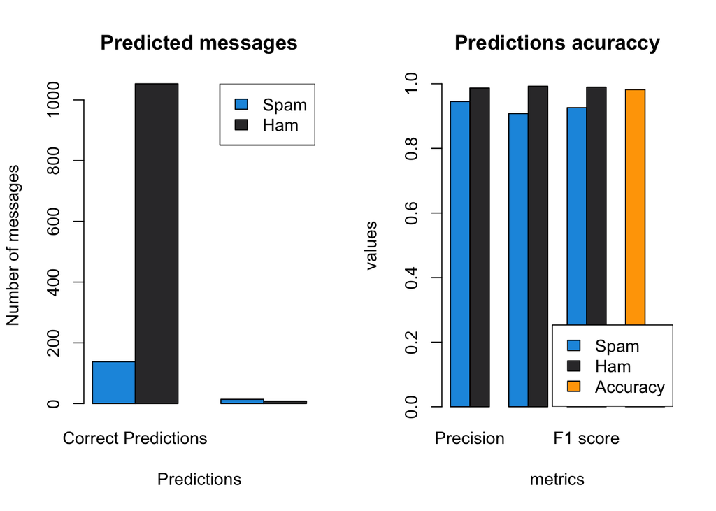

```r
model$fit()
model$score()
```

## Data visualization

*Most frequent words in spam and non-spam:*

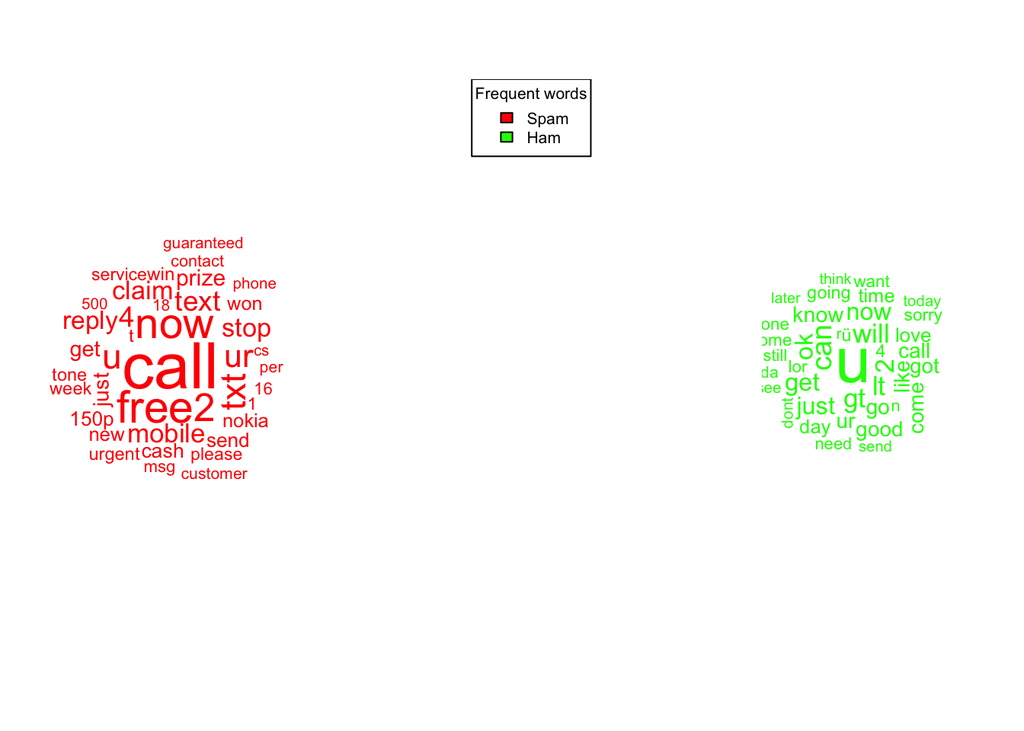

```r
model$frequentWords()
```

## To test the Bayes Classifier on real-world data…

use the predict_from_string() method. Better use longer messages. Some examples would be:

```r
model$predict_from_string("You have won a mobile phone. To get a free phone, call us at humber 2837123792!!!")
```

```
## [1] 0
```

```r
model$predict_from_string("Hey mate, how is your life going?")
```

```
## [1] 1
```